# Read the following cricket dataset : https://taxila-aws.bits-pilani.ac.in/pluginfile.php/1390403/mod_assign/intro/cricketers.csv

a) Identify the all-rounder by the following logic -> Get the players with most runs whose wickets are more than the median wickets of all the players where the players must have taken atleast 1 wicket. [ 3 Marks ]

b) Perform K-means clustering for different values of K (2,3,4,5) and evaluate the quality of clustering using the Silhouette score. [3 points]

c) For each value of K, plot clusters (all cluster points in the same cluster with the same color, cluster points in different clusters in different colors). Use PCA for dimensionality reduction so that the data points can be plotted in 2 - D. Take only 5 data points from each cluster and the point should be labelled with the player name, else 0 marks. [3 pt]

d) Draw a bar graph with X-axis as K value and Y-axis as silhouette score. [1.5 pt]

e) List down 10 players with each cluster and categorize them to the batsman, all-rounder, bowler, etc. [1.5 pt]

References: But not limited to the following:-

PCA: https://towardsdatascience.com/pca-using-python-scikit-learn-e653f8989e60Links to an external site.

Silhouette score: https://towardsdatascience.com/silhouette-coefficient-validating-clustering-techniques-e976bb81d10cLinks to an external site.

```python
# Importing required packages
import numpy as np
import pandas as pd
import warnings as war
war.filterwarnings("ignore")
```

```python
# Defining dataset csv Path
dataSetPath="C:\\Users\\ASUS\\jupyterworkspace\\Assignment & Mini Project\Module_04_Unsupervised Learning and Association Rule Mining\\MiniProject\\cricketers.csv"
# Loading dataSet
dataSetRead=pd.read_csv(dataSetPath, delimiter='\t')
```

```python
# Displaying first 5 records to confirming data loading
print("*****************************************************Displaying below first 5 records**********************************************************")
dataSetRead.head()
```

```
*****************************************************Displaying below first 5 records**********************************************************
```

|  | PLAYER | matches_played | innings_batted | runs_scored | highest_runs | balls_faced | average_runs | strike_rate | innings_bowled | overs | runs_given | wickets_obtained | average_runs_per_wicket | bowling_economy |
| --- | --- | --- | --- | --- | --- | --- | --- | --- | --- | --- | --- | --- | --- | --- |
| 0 | Aaron Finch | 10 | 9 | 134 | 46 | 100 | 16.75 | 144.00 | 0 | 0.0 | 0 | 0 | 0.0 | 0.0 |
| 1 | AB de Villiers | 12 | 11 | 480 | 90 | 275 | 53.33 | 174.54 | 0 | 0.0 | 0 | 0 | 0.0 | 0.0 |
| 2 | Abhishek Sharma | 3 | 3 | 63 | 46 | 33 | 63.00 | 190.90 | 0 | 0.0 | 0 | 0 | 0.0 | 0.0 |
| 3 | Ajinkya Rahane | 15 | 14 | 370 | 65 | 313 | 28.46 | 118.21 | 0 | 0.0 | 0 | 0 | 0.0 | 0.0 |
| 4 | Alex Hales | 6 | 6 | 148 | 45 | 118 | 24.66 | 125.42 | 0 | 0.0 | 0 | 0 | 0.0 | 0.0 |

```python
# Displaying last 5 records to confirming data loading
print("*****************************************************Displaying below last 5 records**********************************************************")
dataSetRead.tail()
```

```
*****************************************************Displaying below last 5 records**********************************************************
```

|  | PLAYER | matches_played | innings_batted | runs_scored | highest_runs | balls_faced | average_runs | strike_rate | innings_bowled | overs | runs_given | wickets_obtained | average_runs_per_wicket | bowling_economy |
| --- | --- | --- | --- | --- | --- | --- | --- | --- | --- | --- | --- | --- | --- | --- |
| 104 | Anureet Singh | 0 | 0 | 0 | 0 | 0 | 0.0 | 0.0 | 3 | 4.0 | 42 | 1 | 42.00 | 10.50 |
| 105 | Avesh Khan | 0 | 0 | 0 | 0 | 0 | 0.0 | 0.0 | 6 | 19.0 | 204 | 4 | 51.00 | 10.73 |
| 106 | Barinder Sran | 0 | 0 | 0 | 0 | 0 | 0.0 | 0.0 | 6 | 22.0 | 229 | 4 | 57.25 | 10.40 |
| 107 | Basil Thampi | 0 | 0 | 0 | 0 | 0 | 0.0 | 0.0 | 4 | 10.1 | 114 | 5 | 22.80 | 10.20 |
| 108 | Ben Laughlin | 0 | 0 | 0 | 0 | 0 | 0.0 | 0.0 | 7 | 21.0 | 212 | 9 | 22.44 | 10.04 |

```python
# Displaying all records to confirming data loading
print("*****************************************************Displaying below all records**********************************************************")
dataSetRead
```

```
*****************************************************Displaying below all records**********************************************************
```

|  | PLAYER | matches_played | innings_batted | runs_scored | highest_runs | balls_faced | average_runs | strike_rate | innings_bowled | overs | runs_given | wickets_obtained | average_runs_per_wicket | bowling_economy |
| --- | --- | --- | --- | --- | --- | --- | --- | --- | --- | --- | --- | --- | --- | --- |
| 0 | Aaron Finch | 10 | 9 | 134 | 46 | 100 | 16.75 | 144.00 | 0 | 0.0 | 0 | 0 | 0.00 | 0.00 |
| 1 | AB de Villiers | 12 | 11 | 480 | 90 | 275 | 53.33 | 174.54 | 0 | 0.0 | 0 | 0 | 0.00 | 0.00 |
| 2 | Abhishek Sharma | 3 | 3 | 63 | 46 | 33 | 63.00 | 190.90 | 0 | 0.0 | 0 | 0 | 0.00 | 0.00 |
| 3 | Ajinkya Rahane | 15 | 14 | 370 | 65 | 313 | 28.46 | 118.21 | 0 | 0.0 | 0 | 0 | 0.00 | 0.00 |
| 4 | Alex Hales | 6 | 6 | 148 | 45 | 118 | 24.66 | 125.42 | 0 | 0.0 | 0 | 0 | 0.00 | 0.00 |
| ... | ... | ... | ... | ... | ... | ... | ... | ... | ... | ... | ... | ... | ... | ... |
| 104 | Anureet Singh | 0 | 0 | 0 | 0 | 0 | 0.00 | 0.00 | 3 | 4.0 | 42 | 1 | 42.00 | 10.50 |
| 105 | Avesh Khan | 0 | 0 | 0 | 0 | 0 | 0.00 | 0.00 | 6 | 19.0 | 204 | 4 | 51.00 | 10.73 |
| 106 | Barinder Sran | 0 | 0 | 0 | 0 | 0 | 0.00 | 0.00 | 6 | 22.0 | 229 | 4 | 57.25 | 10.40 |
| 107 | Basil Thampi | 0 | 0 | 0 | 0 | 0 | 0.00 | 0.00 | 4 | 10.1 | 114 | 5 | 22.80 | 10.20 |
| 108 | Ben Laughlin | 0 | 0 | 0 | 0 | 0 | 0.00 | 0.00 | 7 | 21.0 | 212 | 9 | 22.44 | 10.04 |

109 rows × 14 columns

```python
# Displaying dimension of dataSet
print("Dimention of Dataset:- {}".format(dataSetRead.shape[0:2]))
print("Total number of rows in Dataset:- {}".format(dataSetRead.shape[0]))
print("Total number of columns in Dataset:- {}".format(dataSetRead.shape[1]))
```

```
Dimention of Dataset:- (109, 14)
Total number of rows in Dataset:- 109
Total number of columns in Dataset:- 14
```

```python
# Displaying description & statistcal summary of the dataSet
dataSetRead.describe().T
```

|  | count | mean | std | min | 25% | 50% | 75% | max |
| --- | --- | --- | --- | --- | --- | --- | --- | --- |
| matches_played | 109.0 | 9.559633 | 5.161164 | 0.0 | 5.00 | 10.00 | 14.00 | 17.00 |
| innings_batted | 109.0 | 7.889908 | 4.982078 | 0.0 | 4.00 | 7.00 | 13.00 | 17.00 |
| runs_scored | 109.0 | 173.633028 | 182.356522 | 0.0 | 36.00 | 99.00 | 260.00 | 735.00 |
| highest_runs | 109.0 | 43.495413 | 29.830268 | 0.0 | 20.00 | 40.00 | 62.00 | 128.00 |
| balls_faced | 109.0 | 124.669725 | 123.670265 | 0.0 | 33.00 | 76.00 | 188.00 | 516.00 |
| average_runs | 109.0 | 22.360092 | 16.093453 | 0.0 | 11.80 | 21.16 | 30.00 | 75.83 |
| strike_rate | 109.0 | 122.258716 | 48.576709 | 0.0 | 109.09 | 130.26 | 146.04 | 300.00 |
| innings_bowled | 109.0 | 4.513761 | 5.449456 | 0.0 | 0.00 | 2.00 | 8.00 | 17.00 |
| overs | 109.0 | 13.894495 | 18.395495 | 0.0 | 0.00 | 3.00 | 26.00 | 68.00 |
| runs_given | 109.0 | 119.935780 | 152.807630 | 0.0 | 0.00 | 27.00 | 223.00 | 533.00 |
| wickets_obtained | 109.0 | 3.926606 | 5.602094 | 0.0 | 0.00 | 0.00 | 6.00 | 24.00 |
| average_runs_per_wicket | 109.0 | 17.334862 | 21.910816 | -0.0 | 0.00 | 0.00 | 28.36 | 108.00 |
| bowling_economy | 109.0 | 5.149817 | 4.773435 | 0.0 | 0.00 | 7.28 | 9.23 | 16.50 |

```python
# Displaying the columns and their respective data types
dataSetRead.info()
```

```
<class 'pandas.core.frame.DataFrame'>
RangeIndex: 109 entries, 0 to 108
Data columns (total 14 columns):
 #   Column                    Non-Null Count  Dtype
---  ------                    --------------  -----
 0   PLAYER                    109 non-null    object
 1   matches_played            109 non-null    int64
 2   innings_batted            109 non-null    int64
 3   runs_scored               109 non-null    int64
 4   highest_runs              109 non-null    int64
 5   balls_faced               109 non-null    int64
 6   average_runs              109 non-null    float64
 7   strike_rate               109 non-null    float64
 8   innings_bowled            109 non-null    int64
 9   overs                     109 non-null    float64
 10  runs_given                109 non-null    int64
 11  wickets_obtained          109 non-null    int64
 12  average_runs_per_wicket   109 non-null    float64
 13  bowling_economy           109 non-null    float64
dtypes: float64(5), int64(8), object(1)
memory usage: 12.1+ KB
```

## Question (a):- Identify the all-rounder by the following logic -> Get the players with most runs whose wickets are more than the median wickets of all the players where the players must have taken atleast 1 wicket. [ 3 Marks ]

```python
# displaying player name who obtained at least 1 wicket
dataSetRead_Players_withWicket = dataSetRead[dataSetRead['wickets_obtained'].values >= 1]
```

```python
dataSetRead_Players_withWicket
```

|  | PLAYER | matches_played | innings_batted | runs_scored | highest_runs | balls_faced | average_runs | strike_rate | innings_bowled | overs | runs_given | wickets_obtained | average_runs_per_wicket | bowling_economy |
| --- | --- | --- | --- | --- | --- | --- | --- | --- | --- | --- | --- | --- | --- | --- |
| 6 | Andre Russell | 16 | 14 | 316 | 88 | 171 | 28.72 | 184.79 | 15 | 37.5 | 355 | 13 | 27.30 | 9.38 |
| 7 | Andrew Tye | 14 | 8 | 32 | 14 | 38 | 5.33 | 84.21 | 14 | 56.0 | 448 | 24 | 18.66 | 8.00 |
| 8 | Axar Patel | 9 | 8 | 80 | 19 | 69 | 13.33 | 115.94 | 8 | 26.0 | 218 | 3 | 72.66 | 8.38 |
| 9 | Ben Cutting | 9 | 6 | 96 | 37 | 58 | 24.00 | 165.51 | 7 | 17.0 | 168 | 2 | 84.00 | 9.88 |
| 10 | Ben Stokes | 13 | 13 | 196 | 45 | 161 | 16.33 | 121.73 | 12 | 37.0 | 303 | 8 | 37.87 | 8.18 |
| 11 | Bhuvneshwar Kumar | 12 | 4 | 13 | 7 | 16 | 6.50 | 81.25 | 12 | 46.1 | 354 | 9 | 39.33 | 7.66 |
| 13 | Carlos Brathwaite | 4 | 4 | 75 | 43 | 48 | 25.00 | 156.25 | 4 | 10.1 | 94 | 5 | 18.80 | 9.24 |
| 16 | Chris Morris | 4 | 4 | 46 | 27 | 26 | 46.00 | 176.92 | 4 | 14.0 | 143 | 3 | 47.66 | 10.21 |
| 17 | Chris Woakes | 5 | 4 | 17 | 11 | 19 | 8.50 | 89.47 | 5 | 18.2 | 190 | 8 | 23.75 | 10.36 |
| 18 | Colin de Grandhomme | 9 | 8 | 131 | 40 | 84 | 26.20 | 155.95 | 7 | 15.0 | 129 | 2 | 64.50 | 8.60 |
| 20 | Corey Anderson | 3 | 3 | 17 | 15 | 22 | 5.66 | 77.27 | 3 | 8.4 | 115 | 3 | 38.33 | 13.26 |
| 21 | D'Arcy Short | 7 | 7 | 115 | 44 | 99 | 16.42 | 116.16 | 2 | 3.0 | 19 | 1 | 19.00 | 6.33 |
| 22 | Dan Christian | 4 | 3 | 26 | 13 | 33 | 13.00 | 78.78 | 4 | 11.5 | 101 | 4 | 25.25 | 8.53 |
| 24 | Deepak Chahar | 12 | 4 | 50 | 39 | 29 | 16.66 | 172.41 | 12 | 38.1 | 278 | 10 | 27.80 | 7.28 |
| 27 | Dwayne Bravo | 16 | 10 | 141 | 68 | 91 | 35.25 | 154.94 | 16 | 53.3 | 533 | 14 | 38.07 | 9.96 |
| 31 | Glenn Maxwell | 12 | 12 | 169 | 47 | 120 | 14.08 | 140.83 | 10 | 16.0 | 132 | 5 | 26.40 | 8.25 |
| 32 | Harbhajan Singh | 13 | 3 | 29 | 19 | 36 | 9.66 | 80.55 | 12 | 31.5 | 270 | 7 | 38.57 | 8.48 |
| 33 | Hardik Pandya | 13 | 13 | 260 | 50 | 195 | 28.88 | 133.33 | 13 | 42.4 | 381 | 18 | 21.16 | 8.92 |
| 34 | Harshal Patel | 5 | 2 | 60 | 36 | 33 | 60.00 | 181.81 | 5 | 17.3 | 167 | 7 | 23.85 | 9.54 |
| 38 | Jaydev U0dkat | 15 | 7 | 49 | 26 | 38 | 12.25 | 128.94 | 15 | 50.2 | 486 | 11 | 44.18 | 9.65 |
| 39 | Jofra Archer | 10 | 8 | 15 | 8 | 21 | 3.00 | 71.42 | 10 | 38.5 | 325 | 15 | 21.66 | 8.36 |
| 46 | Krish0ppa Gowtham | 15 | 13 | 126 | 33 | 64 | 14.00 | 196.87 | 15 | 40.0 | 312 | 11 | 28.36 | 7.80 |
| 47 | Kru0l Pandya | 14 | 13 | 228 | 41 | 157 | 22.80 | 145.22 | 13 | 40.1 | 284 | 12 | 23.66 | 7.07 |
| 54 | Marcus Stoinis | 7 | 7 | 99 | 29 | 76 | 24.75 | 130.26 | 6 | 11.0 | 120 | 3 | 40.00 | 10.90 |
| 56 | Mayank Markande | 14 | 6 | 21 | 7 | 24 | 10.50 | 87.50 | 14 | 44.0 | 368 | 15 | 24.53 | 8.36 |
| 57 | Mitchell Johnson | 6 | 2 | 16 | 12 | 11 | -0.00 | 145.45 | 6 | 21.0 | 216 | 2 | 108.00 | 10.28 |
| 58 | Moeen Ali | 5 | 4 | 77 | 65 | 46 | 19.25 | 167.39 | 5 | 13.1 | 97 | 3 | 32.33 | 7.36 |
| 59 | Mohammad 0bi | 2 | 2 | 18 | 14 | 12 | 9.00 | 150.00 | 2 | 5.0 | 47 | 1 | 47.00 | 9.40 |
| 60 | Mohammed Siraj | 11 | 4 | 25 | 14 | 22 | 12.50 | 113.63 | 11 | 41.0 | 367 | 11 | 33.36 | 8.95 |
| 62 | Nitish Ra0 | 15 | 15 | 304 | 59 | 232 | 23.38 | 131.03 | 5 | 6.1 | 44 | 4 | 11.00 | 7.13 |
| 64 | Piyush Chawla | 15 | 7 | 27 | 12 | 34 | 6.75 | 79.41 | 15 | 49.0 | 412 | 14 | 29.42 | 8.40 |
| 67 | Rahul Tewatia | 8 | 5 | 50 | 24 | 43 | 16.66 | 116.27 | 8 | 22.0 | 173 | 6 | 28.83 | 7.86 |
| 69 | Rashid Khan | 17 | 7 | 59 | 34 | 31 | 11.80 | 190.32 | 17 | 68.0 | 458 | 21 | 21.80 | 6.73 |
| 70 | Ravichandran Ashwin | 14 | 9 | 102 | 45 | 71 | 12.75 | 143.66 | 14 | 50.4 | 410 | 10 | 41.00 | 8.09 |
| 71 | Ravindra Jadeja | 16 | 10 | 89 | 27 | 74 | 17.80 | 120.27 | 14 | 41.0 | 303 | 11 | 27.54 | 7.39 |
| 79 | Shakib Al Hasan | 17 | 13 | 239 | 35 | 197 | 21.72 | 121.31 | 17 | 57.0 | 456 | 14 | 32.57 | 8.00 |
| 80 | Shane Watson | 15 | 15 | 555 | 117 | 359 | 39.64 | 154.59 | 11 | 28.0 | 251 | 6 | 41.83 | 8.96 |
| 81 | Shardul Thakur | 13 | 1 | 15 | 15 | 5 | -0.00 | 300.00 | 13 | 46.4 | 431 | 16 | 26.93 | 9.23 |
| 83 | Shivam Mavi | 9 | 4 | 13 | 7 | 15 | 4.33 | 86.66 | 9 | 28.0 | 270 | 5 | 54.00 | 9.64 |
| 85 | Shreyas Gopal | 11 | 4 | 50 | 24 | 45 | 16.66 | 111.11 | 10 | 31.0 | 236 | 11 | 21.45 | 7.61 |
| 89 | Sunil 0rine | 16 | 16 | 357 | 75 | 188 | 22.31 | 189.89 | 16 | 61.0 | 467 | 17 | 27.47 | 7.65 |
| 92 | Tim Southee | 8 | 4 | 52 | 36 | 46 | 26.00 | 113.04 | 8 | 29.0 | 261 | 5 | 52.20 | 9.00 |
| 93 | Tom Curran | 5 | 4 | 23 | 18 | 28 | 7.66 | 82.14 | 5 | 10.1 | 118 | 6 | 19.66 | 11.60 |
| 94 | Vijay Shankar | 13 | 11 | 212 | 54 | 148 | 53.00 | 143.24 | 4 | 5.0 | 58 | 1 | 58.00 | 11.60 |
| 96 | Washington Sundar | 7 | 6 | 65 | 35 | 38 | 21.66 | 171.05 | 7 | 20.0 | 192 | 4 | 48.00 | 9.60 |
| 98 | Yusuf Pathan | 15 | 13 | 260 | 45 | 200 | 28.88 | 130.00 | 1 | 2.0 | 14 | 1 | 14.00 | 7.00 |
| 101 | Amit Mishra | 0 | 0 | 0 | 0 | 0 | 0.00 | 0.00 | 10 | 37.0 | 264 | 12 | 22.00 | 7.13 |
| 102 | Ankit Rajpoot | 0 | 0 | 0 | 0 | 0 | 0.00 | 0.00 | 8 | 26.1 | 223 | 11 | 20.27 | 8.52 |
| 104 | Anureet Singh | 0 | 0 | 0 | 0 | 0 | 0.00 | 0.00 | 3 | 4.0 | 42 | 1 | 42.00 | 10.50 |
| 105 | Avesh Khan | 0 | 0 | 0 | 0 | 0 | 0.00 | 0.00 | 6 | 19.0 | 204 | 4 | 51.00 | 10.73 |
| 106 | Barinder Sran | 0 | 0 | 0 | 0 | 0 | 0.00 | 0.00 | 6 | 22.0 | 229 | 4 | 57.25 | 10.40 |
| 107 | Basil Thampi | 0 | 0 | 0 | 0 | 0 | 0.00 | 0.00 | 4 | 10.1 | 114 | 5 | 22.80 | 10.20 |
| 108 | Ben Laughlin | 0 | 0 | 0 | 0 | 0 | 0.00 | 0.00 | 7 | 21.0 | 212 | 9 | 22.44 | 10.04 |

```python
# Calculating Median of wickets obtained
Wickets_Median = dataSetRead_Players_withWicket['wickets_obtained'].median()
print("Meadian of wickets {}".format(Wickets_Median))
```

```
Meadian of wickets 7.0
```

```python
#  Fetching description details of all-rounders
Allrounders_dataSetRead = dataSetRead_Players_withWicket[dataSetRead_Players_withWicket['wickets_obtained'].values > Wickets_Median]
Allrounders_dataSetRead.describe()
```

|  | matches_played | innings_batted | runs_scored | highest_runs | balls_faced | average_runs | strike_rate | innings_bowled | overs | runs_given | wickets_obtained | average_runs_per_wicket | bowling_economy |
| --- | --- | --- | --- | --- | --- | --- | --- | --- | --- | --- | --- | --- | --- |
| count | 25.000000 | 25.000000 | 25.00000 | 25.000000 | 25.000000 | 25.000000 | 25.000000 | 25.000000 | 25.000000 | 25.00000 | 25.000000 | 25.000000 | 25.000000 |
| mean | 11.960000 | 7.520000 | 97.08000 | 28.720000 | 67.640000 | 13.240400 | 120.867200 | 12.720000 | 42.812000 | 354.24000 | 13.000000 | 28.103200 | 8.348800 |
| std | 5.191981 | 4.814215 | 107.14162 | 23.821419 | 67.859463 | 9.700819 | 67.651465 | 3.075711 | 11.699192 | 93.66175 | 3.937004 | 7.196091 | 0.993845 |
| min | 0.000000 | 0.000000 | 0.00000 | 0.000000 | 0.000000 | 0.000000 | 0.000000 | 5.000000 | 18.200000 | 190.00000 | 8.000000 | 18.660000 | 6.730000 |
| 25% | 11.000000 | 4.000000 | 17.00000 | 11.000000 | 21.000000 | 6.500000 | 84.210000 | 11.000000 | 37.500000 | 284.00000 | 11.000000 | 22.000000 | 7.650000 |
| 50% | 14.000000 | 7.000000 | 50.00000 | 26.000000 | 38.000000 | 12.500000 | 121.310000 | 13.000000 | 41.000000 | 355.00000 | 12.000000 | 27.300000 | 8.180000 |
| 75% | 15.000000 | 13.000000 | 141.00000 | 41.000000 | 91.000000 | 17.800000 | 154.940000 | 15.000000 | 50.200000 | 431.00000 | 15.000000 | 32.570000 | 8.950000 |
| max | 17.000000 | 16.000000 | 357.00000 | 88.000000 | 197.000000 | 35.250000 | 300.000000 | 17.000000 | 68.000000 | 533.00000 | 24.000000 | 44.180000 | 10.360000 |

```python
# Displaying allrounders details in descending orders based on run scored
Allrounders_dataSetRead.sort_values(by='runs_scored',ascending=False)
```

|  | PLAYER | matches_played | innings_batted | runs_scored | highest_runs | balls_faced | average_runs | strike_rate | innings_bowled | overs | runs_given | wickets_obtained | average_runs_per_wicket | bowling_economy |
| --- | --- | --- | --- | --- | --- | --- | --- | --- | --- | --- | --- | --- | --- | --- |
| 89 | Sunil 0rine | 16 | 16 | 357 | 75 | 188 | 22.31 | 189.89 | 16 | 61.0 | 467 | 17 | 27.47 | 7.65 |
| 6 | Andre Russell | 16 | 14 | 316 | 88 | 171 | 28.72 | 184.79 | 15 | 37.5 | 355 | 13 | 27.30 | 9.38 |
| 33 | Hardik Pandya | 13 | 13 | 260 | 50 | 195 | 28.88 | 133.33 | 13 | 42.4 | 381 | 18 | 21.16 | 8.92 |
| 79 | Shakib Al Hasan | 17 | 13 | 239 | 35 | 197 | 21.72 | 121.31 | 17 | 57.0 | 456 | 14 | 32.57 | 8.00 |
| 47 | Kru0l Pandya | 14 | 13 | 228 | 41 | 157 | 22.80 | 145.22 | 13 | 40.1 | 284 | 12 | 23.66 | 7.07 |
| 10 | Ben Stokes | 13 | 13 | 196 | 45 | 161 | 16.33 | 121.73 | 12 | 37.0 | 303 | 8 | 37.87 | 8.18 |
| 27 | Dwayne Bravo | 16 | 10 | 141 | 68 | 91 | 35.25 | 154.94 | 16 | 53.3 | 533 | 14 | 38.07 | 9.96 |
| 46 | Krish0ppa Gowtham | 15 | 13 | 126 | 33 | 64 | 14.00 | 196.87 | 15 | 40.0 | 312 | 11 | 28.36 | 7.80 |
| 70 | Ravichandran Ashwin | 14 | 9 | 102 | 45 | 71 | 12.75 | 143.66 | 14 | 50.4 | 410 | 10 | 41.00 | 8.09 |
| 71 | Ravindra Jadeja | 16 | 10 | 89 | 27 | 74 | 17.80 | 120.27 | 14 | 41.0 | 303 | 11 | 27.54 | 7.39 |
| 69 | Rashid Khan | 17 | 7 | 59 | 34 | 31 | 11.80 | 190.32 | 17 | 68.0 | 458 | 21 | 21.80 | 6.73 |
| 24 | Deepak Chahar | 12 | 4 | 50 | 39 | 29 | 16.66 | 172.41 | 12 | 38.1 | 278 | 10 | 27.80 | 7.28 |
| 85 | Shreyas Gopal | 11 | 4 | 50 | 24 | 45 | 16.66 | 111.11 | 10 | 31.0 | 236 | 11 | 21.45 | 7.61 |
| 38 | Jaydev U0dkat | 15 | 7 | 49 | 26 | 38 | 12.25 | 128.94 | 15 | 50.2 | 486 | 11 | 44.18 | 9.65 |
| 7 | Andrew Tye | 14 | 8 | 32 | 14 | 38 | 5.33 | 84.21 | 14 | 56.0 | 448 | 24 | 18.66 | 8.00 |
| 64 | Piyush Chawla | 15 | 7 | 27 | 12 | 34 | 6.75 | 79.41 | 15 | 49.0 | 412 | 14 | 29.42 | 8.40 |
| 60 | Mohammed Siraj | 11 | 4 | 25 | 14 | 22 | 12.50 | 113.63 | 11 | 41.0 | 367 | 11 | 33.36 | 8.95 |
| 56 | Mayank Markande | 14 | 6 | 21 | 7 | 24 | 10.50 | 87.50 | 14 | 44.0 | 368 | 15 | 24.53 | 8.36 |
| 17 | Chris Woakes | 5 | 4 | 17 | 11 | 19 | 8.50 | 89.47 | 5 | 18.2 | 190 | 8 | 23.75 | 10.36 |
| 39 | Jofra Archer | 10 | 8 | 15 | 8 | 21 | 3.00 | 71.42 | 10 | 38.5 | 325 | 15 | 21.66 | 8.36 |
| 81 | Shardul Thakur | 13 | 1 | 15 | 15 | 5 | -0.00 | 300.00 | 13 | 46.4 | 431 | 16 | 26.93 | 9.23 |
| 11 | Bhuvneshwar Kumar | 12 | 4 | 13 | 7 | 16 | 6.50 | 81.25 | 12 | 46.1 | 354 | 9 | 39.33 | 7.66 |
| 101 | Amit Mishra | 0 | 0 | 0 | 0 | 0 | 0.00 | 0.00 | 10 | 37.0 | 264 | 12 | 22.00 | 7.13 |
| 102 | Ankit Rajpoot | 0 | 0 | 0 | 0 | 0 | 0.00 | 0.00 | 8 | 26.1 | 223 | 11 | 20.27 | 8.52 |
| 108 | Ben Laughlin | 0 | 0 | 0 | 0 | 0 | 0.00 | 0.00 | 7 | 21.0 | 212 | 9 | 22.44 | 10.04 |

## Question (b):- Perform K-means clustering for different values of K (2,3,4,5) and evaluate the quality of clustering using the Silhouette score. [3 points]¶

```python
# Importing required packages
from sklearn.cluster import KMeans
from sklearn.metrics import silhouette_score
from sklearn.preprocessing import MinMaxScaler

# Selecting all numerical features for K-Means Cl
New_dataSetRead = dataSetRead.select_dtypes(include=['float64', 'int64']).copy()

# Standardize the data for K-means clustering
scaler = MinMaxScaler()
scaled_data = scaler.fit_transform(New_dataSetRead)

# Dictionary to store Silhouette scores for each K value
silhouette_scores = {}

# Perform K-means clustering for K values 2, 3, 4, and 5
for k in [2, 3, 4, 5]:
    kmeans = KMeans(n_clusters=k, random_state=42)
    cluster_labels = kmeans.fit_predict(scaled_data)
    score = silhouette_score(scaled_data, cluster_labels)
    silhouette_scores[k] = score
    print(f'Silhouette Score for K={k}: {score:.5f}')
# Identify the best K value based on the highest silhouette score
Best_K_Value = max(silhouette_scores, key=silhouette_scores.get)
print(f"\nBest K value: {Best_K_Value } with a Silhouette Score of {silhouette_scores[Best_K_Value]:.5f}")
```

```
Silhouette Score for K=2: 0.37118
Silhouette Score for K=3: 0.38084
Silhouette Score for K=4: 0.38135
Silhouette Score for K=5: 0.37025

Best K value: 4 with a Silhouette Score of 0.38135
```

#### Analysis:-

The silhouette score generally indicates how well-separated and compact the clusters are, with higher scores being preferable. In this case:

The highest silhouette score is at 𝐾=4 (0.38135), suggesting this value likely offers the best cluster separation among the tested values.

The score drops slightly at 𝐾=5 indicating that increasing clusters beyond 𝐾=4 may introduce some overlap or reduce the compactness of clusters.

Based on these values, 𝐾=4 seems like the optimal choice for achieving the best-defined clusters with the data you have.

## Question (c):-For each value of K, plot clusters (all cluster points in the same cluster with the same color, cluster points in different clusters in different colors). Use PCA for dimensionality reduction so that the data points can be plotted in 2 - D. Take only 5 data points from each cluster and the point should be labelled with the player name, else 0 marks. [3 pt]

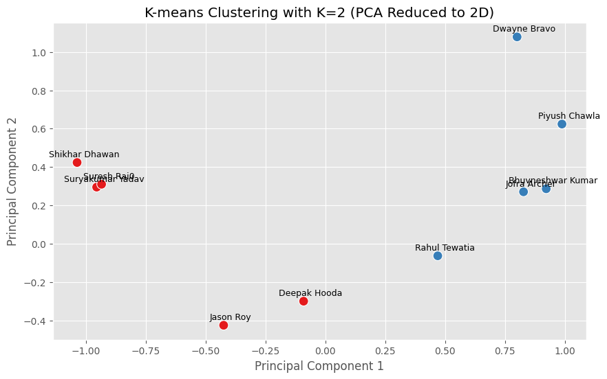

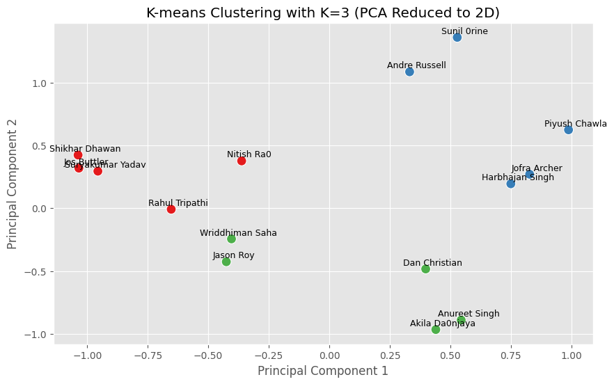

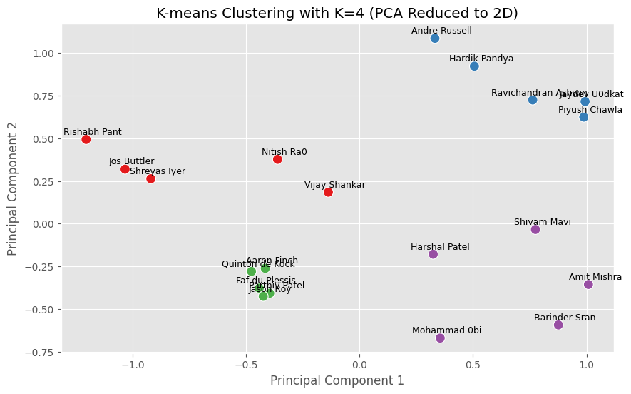

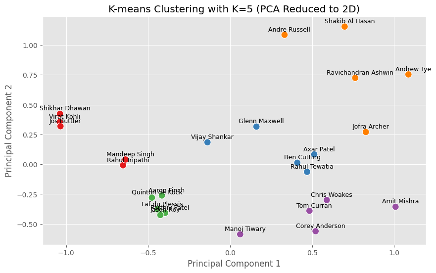

```python
# importing required packages
import matplotlib.pyplot as plt
from sklearn.decomposition import PCA
from sklearn.cluster import KMeans
import seaborn as sns
import pandas as pd

# Perform PCA for dimensionality reduction (to 2D)
pca = PCA(n_components=2)
X_pca = pca.fit_transform(scaled_data)

# Loop through each K (number of clusters)
for k in range(2, 6):
    kmeans = KMeans(n_clusters=k, random_state=42)
    clusters = kmeans.fit_predict(scaled_data)

    # Create an empty DataFrame to hold only the selected points
    selected_points = pd.DataFrame(columns=['PCA1', 'PCA2', 'Cluster', 'Player'])

    # Select only 5 points from each cluster for display
    for cluster_num in range(k):
        # Get indices of points in the current cluster
        cluster_indices = pd.Series(range(len(clusters)))[clusters == cluster_num]

        # Randomly select 5 indices from the cluster
        if len(cluster_indices) > 5:
            selected_indices = cluster_indices.sample(5, random_state=42).values
        else:
            selected_indices = cluster_indices.values  # If fewer than 5, take all points

        # Collect selected points into a temporary DataFrame
        temp_df = pd.DataFrame({
            'PCA1': X_pca[selected_indices, 0],
            'PCA2': X_pca[selected_indices, 1],
            'Cluster': cluster_num,
            'Player': dataSetRead.loc[selected_indices, 'PLAYER']  # Get player names from df
        })

        # Append temp_df to selected_points
        selected_points = pd.concat([selected_points, temp_df], ignore_index=True)

    # Plot only the selected points with labels
    plt.figure(figsize=(10, 6))
    sns.scatterplot(data=selected_points, x='PCA1', y='PCA2', hue='Cluster', palette="Set1", s=100, marker="o", legend=None)

   # Annotate each selected point with the player name
    for _, row in selected_points.iterrows():
        plt.text(row['PCA1'] + 0.03, row['PCA2'] + 0.03, row['Player'], fontsize=9, ha='center', color='black')

    # Set plot title and labels
    plt.title(f'K-means Clustering with K={k} (PCA Reduced to 2D)')
    plt.xlabel('Principal Component 1')
    plt.ylabel('Principal Component 2')
    plt.show()
```

## Question (d):-Draw a bar graph with X-axis as K value and Y-axis as silhouette score. [1.5 pt]

```
The dictionary contains K values and corresponding silhouette score from question (b):

{2: 0.3711813404418582, 3: 0.3808399859723335, 4: 0.38135494702813433, 5: 0.3702497715206442}
```

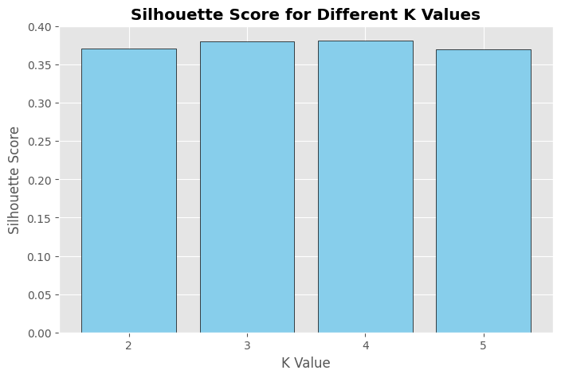

```python
# Values for K and corresponding silhouette scores
print('***********************************************************************************************************************')
print('The dictionary contains K values and corresponding silhouette score from question (b): ')
print('  ')
print(silhouette_scores)
print('***********************************************************************************************************************')
k_values = list(silhouette_scores.keys())
silhouette_values = list(silhouette_scores.values())

# Plotting the bar graph
plt.figure(figsize=(8, 5))
plt.style.use('ggplot')
plt.bar(k_values, silhouette_values, color='skyblue',edgecolor='black')
plt.xlabel('K Value')
plt.ylabel('Silhouette Score')
plt.title('Silhouette Score for Different K Values',fontweight='bold')
plt.xticks(k_values)
plt.show()
```

## Question (e):-List down 10 players with each cluster and categorize them to the batsman, all-rounder, bowler, etc. [1.5 pt]

```python
# Step (e): List down 10 players with each cluster and categorize them
print(silhouette_scores)
print('best_k:', best_k)
# Final clustering step to get cluster labels for the best K (highest silhouette score)
best_k = max(silhouette_scores, key=silhouette_scores.get)
final_kmeans = KMeans(n_clusters=best_k, random_state=42, n_init=10)
final_cluster_labels = final_kmeans.fit_predict(scaled_data)

# Add cluster labels to the dataframe
dataSetRead['cluster'] = final_cluster_labels

# Group players by their cluster and list down 10 players from each
clustered_players = {}
for cluster in range(best_k):
    players_in_cluster = dataSetRead[dataSetRead['cluster'] == cluster]['PLAYER'].head(10).tolist()
    clustered_players[f'Cluster {cluster + 1}'] = players_in_cluster

# Display the categorized players from each cluster
for cluster, players in clustered_players.items():
    print(f"{cluster}: {players}")
```

```
{2: 0.3711813404418582, 3: 0.3808399859723335, 4: 0.38135494702813433, 5: 0.3702497715206442}
best_k: 4
Cluster 1: ['AB de Villiers', 'Ajinkya Rahane', 'Ambati Rayudu', 'Chris Gayle', 'Chris Lynn', 'Dinesh Karthik', 'Evin Lewis', 'Ishan Kishan', 'Jos Buttler', 'Kane Williamson ']
Cluster 2: ['Andre Russell', 'Andrew Tye', 'Ben Stokes', 'Bhuvneshwar Kumar', 'Deepak Chahar', 'Dwayne Bravo', 'Glenn Maxwell', 'Harbhajan Singh', 'Hardik Pandya', 'Jaydev U0dkat']
Cluster 3: ['Aaron Finch', 'Abhishek Sharma', 'Alex Hales', 'Brendon McCullum', 'Colin Munro', "D'Arcy Short", 'David Miller', 'Deepak Hooda', 'Faf du Plessis', 'Gautam Gambhir']
Cluster 4: ['Axar Patel', 'Ben Cutting', 'Carlos Brathwaite', 'Chris Morris', 'Chris Woakes', 'Colin de Grandhomme', 'Corey Anderson', 'Dan Christian', 'Harshal Patel', 'JP Duminy']
```

```python
dataSetRead['cluster'].value_counts()
```

```
cluster
3    32
0    30
2    24
1    23
Name: count, dtype: int64
```

```python
# Set option to display maximum rows in the DataFrame
pd.reset_option('display.max_rows', None)  # None displays all rows
```

```python
# Function to classify players based on statistical thresholds
def classify_player(row):
    if row['wickets_obtained'] > 10 and row['runs_scored'] < 100:
        return 'Bowler'
    elif row['wickets_obtained'] > 10 and row['runs_scored'] >= 100:
        return 'All-Rounder'
    elif row['runs_scored'] >= 200 and row['wickets_obtained'] < 10:
        return 'Batsman'
    elif row['wickets_obtained'] == 0:
        return 'Batsman'
    else:
        return 'All-Rounder'  # Default fallback

# Apply the classification function to the dataframe
dataSetRead['Role'] = dataSetRead.apply(classify_player, axis=1)

# Group by Cluster and display 10 players from each cluster
clustered_players = dataSetRead.groupby('cluster').apply(lambda x: x.sample(n=10, random_state=42) if len(x) >= 10 else x)
clustered_players = clustered_players.reset_index(drop=True)  # Reset index to avoid ambiguity

# Display the result
for cluster, group in clustered_players.groupby('cluster'):
    print(f"\nCluster {cluster} - Sampled Players:")
    print(group[['PLAYER', 'Role']])
```

```
Cluster 0 - Sampled Players:
             PLAYER     Role
0     Vijay Shankar  Batsman
1        Nitish Ra0  Batsman
2      Shreyas Iyer  Batsman
3      Rishabh Pant  Batsman
4       Jos Buttler  Batsman
5  Kane Williamson   Batsman
6       Virat Kohli  Batsman
7      Shubman Gill  Batsman
8     Mandeep Singh  Batsman
9    AB de Villiers  Batsman

Cluster 1 - Sampled Players:
                 PLAYER         Role
```

[output cut: 36 more lines]